# Orange Roughy Eastern Zone: Biological Summary from the Acoustic Survey 2024

Standard Length (cm) vs weight (kg) for the Eastern Zone spawning population from 1987 to 2019 for both grounds combined, showing the predicted values (plotted black line) from Lyle (1991).

NOTE - this has been corrected as per the above - the correct combined Lyle formula has replaced the Lyle Male formula!!

* Lyle et al. Combined length – weight regression. W = 3.7*10-2* ^2.952

Lyle et al. Female length – weight regression. W = 3.51*10-2* ^2.970

Lyle et al. Male length – weight regression. W = 3.83*10-2* ^2.942 and

OR Weight vs Length series by year

``` r OR_Weight_series <- OR_Weight_series_allyears %>% drop_na(weight_kg) %>% filter(weight_kg != 0)

Lyle_com_kg <- function(x) {(0.037 * (x) ^ 2.952)/1000}

f2.7<- ggplot(data = OR_Weight_series, mapping = aes(x = Length, y = weight_kg, colour = year)) + geom_point()+ #geom_smooth(method=“glm”, method.args=list(family=gaussian(link=“log”)), #colour = “blue”, linetype = 2, size = .5)+ ylab(“weight (kg)”)+ xlab(“Standard length (cm)”)+ stat_function(fun = Lyle_com_kg, colour =“black”)+ facet_wrap(~year)

plot(f2.7) ```

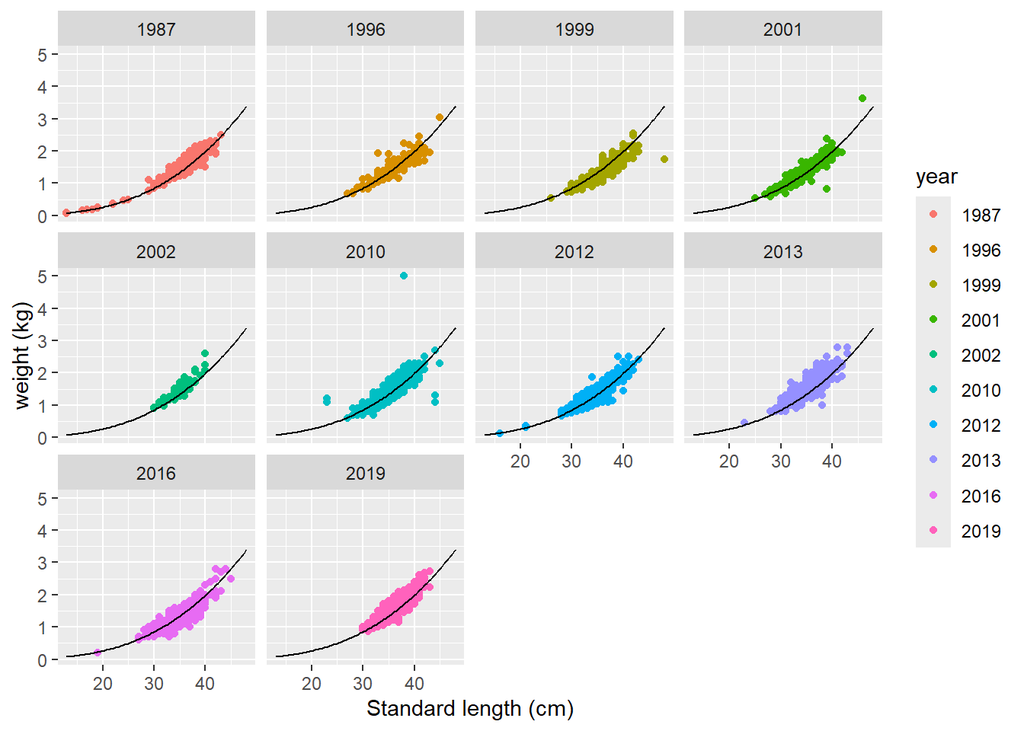

`r ggsave("Figures/LWindex.emf",f2.7)`

`## Saving 7 x 5 in image`

`r ggsave("Figures/LWindex.jpg",f2.7)# saves the plot to file :)`

`## Saving 7 x 5 in image`

`r plot(f2.7)`

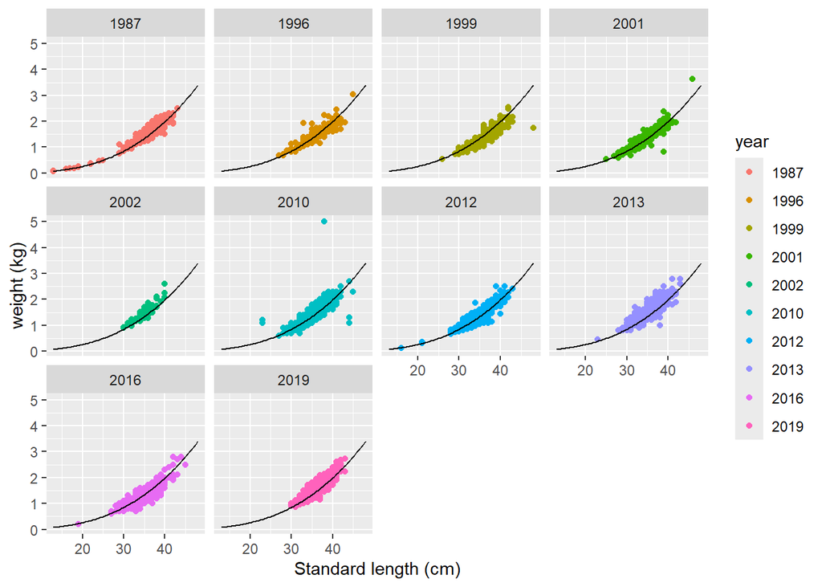

#### calculate change in LW relationship

`r OR_Weight_series %>% group_by(Ground,year) %>% dplyr::summarise(n(),MvsD = round(mean(MvsD),2), perchange = round(mean(percentchange),2))`

`` ## `summarise()` has grouped output by 'Ground'. You can override using the ## `.groups` argument. ``

`` ## # A tibble: 18 × 5 ## # Groups: Ground [2] ## Ground year `n()` MvsD perchange ## <chr> <fct> <int> <dbl> <dbl> ## 1 St Helens 1996 177 0.98 -0.03 ## 2 St Helens 1999 259 0.92 -0.1 ## 3 St Helens 2001 125 1.03 0.02 ## 4 St Helens 2010 1059 1.01 0 ## 5 St Helens 2012 561 1.01 0.01 ## 6 St Helens 2013 832 1.08 0.06 ## 7 St Helens 2016 588 0.98 -0.04 ## 8 St Helens 2019 448 1.03 0.03 ## 9 St Patricks 1987 327 1.04 0.04 ## 10 St Patricks 1996 20 1.07 0.04 ## 11 St Patricks 1999 151 0.91 -0.11 ## 12 St Patricks 2001 248 1.01 0 ## 13 St Patricks 2002 79 1.07 0.06 ## 14 St Patricks 2010 388 1.05 0.04 ## 15 St Patricks 2012 602 1.01 0 ## 16 St Patricks 2013 210 1.11 0.09 ## 17 St Patricks 2016 154 0.99 -0.02 ## 18 St Patricks 2019 391 1.04 0.04 ``